# R Notebook

### Import Libraries

```r
install.packages("astsa")
library(astsa)
```

## Askisi 5:

Τα στοιχεία του πίνακα παρουσιάζουν τις πωλήσεις μπίρας μίας βιομηχανίας (σε εκατομμύρια μπουκάλια) ανά περιοχή από το 2016μέχρι το 2019 1. Να υπολογιστούν οι εποχιακοί δείκτες 2. Να γίνει εξάλειψη της εποχικότητας χρησιμοποιώντας του δείκτες εποχικότητας Να προσαρμοστεί η γραμμική τάση 3. Να υπολογιστεί η σχετική τάση 4. Να γίνει πρόβλεψη των πωλήσεων για το καλοκαίρι του 2020

### Bima 1:

Fortonoume ta dedomena se ena R array.

```r
# declare data per year
data2016 = c(3.1, 5.1, 5.3, 3.6)
data2017 = c(3.3, 5.1, 5.8, 3.7)
data2018 = c(3.4, 5.3, 6, 3.8)
data2019 = c(3.7, 5.4, 6.1, 3.9)

# combin data
data = append(data2016, data2017)
data = append(data, data2018)
data = append(data, data2019)

data
```

```
 [1] 3.1 5.1 5.3 3.6 3.3 5.1 5.8 3.7 3.4 5.3 6.0 3.8 3.7 5.4 6.1 3.9
```

### Bima 2:

Pragmatopoioume elenxo ton dedomenon gia tin kaliteri katanoisi tous: - Elenxoume an ta data einai xronoseira. - Provaloume tin xronoseira - Ipologizoume ta ACF kai PACF

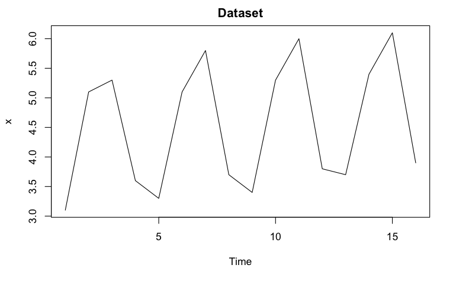

```r
x=ts(data)

# plot cmort data
plot.ts(x, main="Dataset")
```

```
      [,1]  [,2]  [,3] [,4]  [,5]  [,6] [,7]  [,8]  [,9] [,10]
ACF  -0.04 -0.78  0.05 0.74 -0.04 -0.60 0.04  0.47 -0.06 -0.37
PACF -0.04 -0.78 -0.07 0.34  0.13  0.16 0.00 -0.23 -0.18 -0.04
```

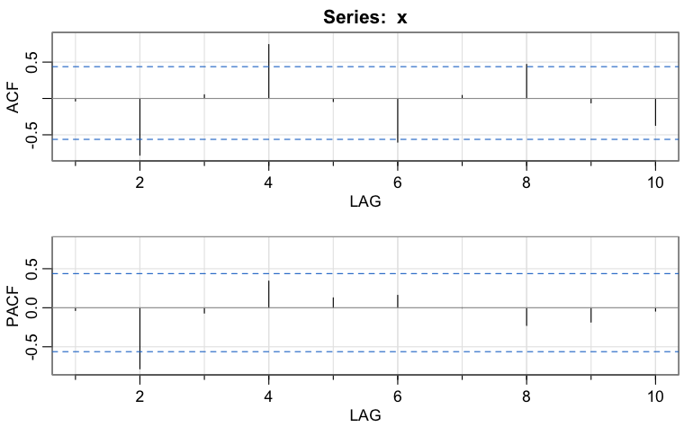

```r
# plot PACF
acf2(x,10)
```

### Bima 3:

Paratiroume oti i xronosira den einai stasimi. Diladi:

Parateoume oti sta dedomena ipaexei epoxikotita kai poio sigkekrimena quarterly seasonality diladi S = 4. Episis Paratirite kai mia anodiki tasi stin xronosira Arxika provaloume tin euthia tis tasis kanontas decompose ta data mas

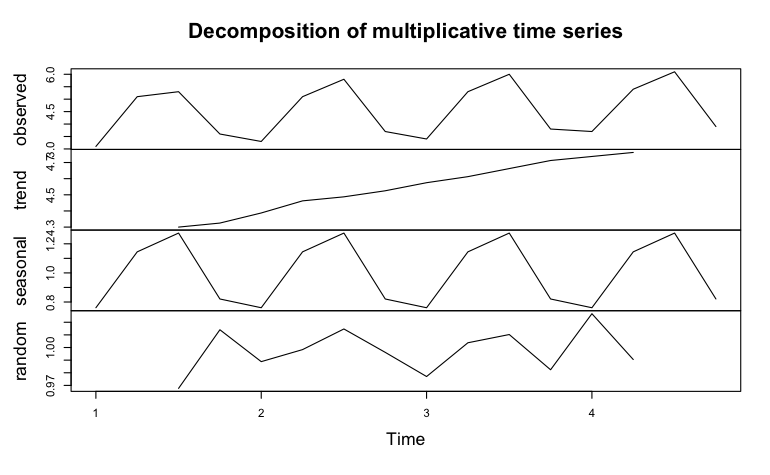

```r
ts_data = ts(data, freq = 4)
decomp_data = decompose (ts_data, type = "multiplicative")
plot (decomp_data)
```

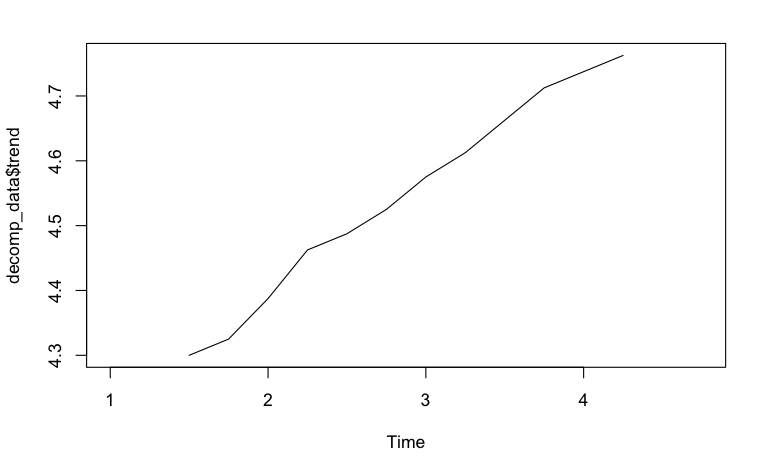

```r
plot (decomp_data$trend)
```

`` **Epilisi tou parapano thematos** Gia na epilisoume to parapano thema litourgoume ws eksis: 1. Dilonoume oti i xronosira exei sixnotita 4 (dedomenou oti exei quardatic trend) 2. Apalifoume tin epoxikotita pernontas tis 4es diafores 3. Apalifoume tin tasi pernontas tin 1i diafora afou exoume parei tis 4 diafores

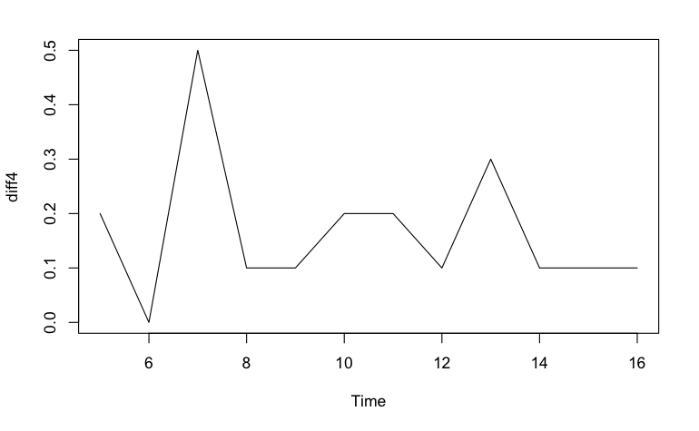

```r
# take 4th diffs to remove seasonality from data
diff4 = diff(x, 4)
plot.ts(diff4)
```

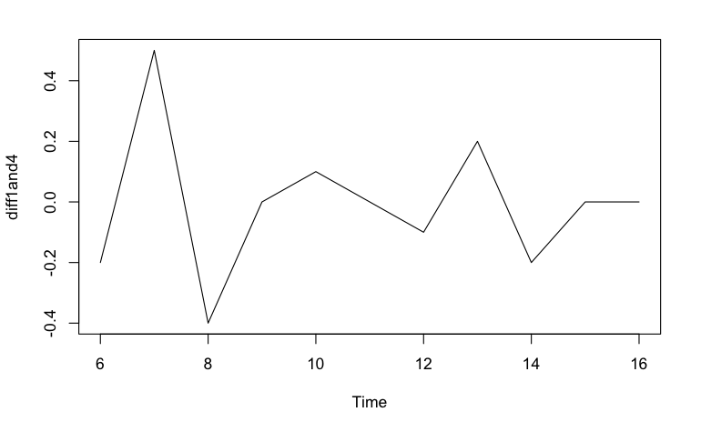

```r
# take 1st diffs to remove trend from data
diff1and4 = diff(diff4,1)
plot.ts(diff1and4)
```

```
      [,1]  [,2]  [,3]  [,4]  [,5]  [,6]
ACF  -0.65  0.08  0.13  0.00 -0.24  0.36
PACF -0.65 -0.60 -0.48 -0.16 -0.44 -0.21
```

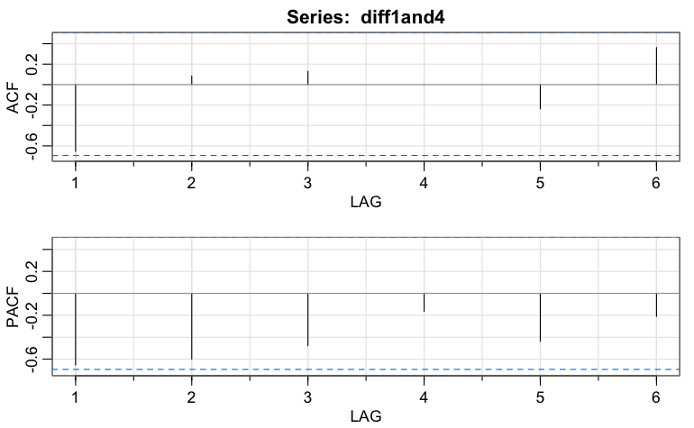

```r
acf2(diff1and4)
```

### Fit Arima model

```r
# apply diff data on ARIMA(2,0,0)
fitARIMA <- arima(diff1and4, order=c(2,0,2), seasonal = c(1,0,0))
fitARIMA
```

```
Call:
arima(x = diff1and4, order = c(2, 0, 2), seasonal = c(1, 0, 0))

Coefficients:
          ar1      ar2      ma1      ma2     sar1  intercept
      -0.6982  -0.7828  -0.0156  -0.9843  -0.9999    -0.0079
s.e.   0.1996   0.1777   0.3509   0.3477   0.0029     0.0029

sigma^2 estimated as 0.004236:  log likelihood = 10.24,  aic = -6.49
```

### Provlepsei ws to Fthinopoorou tou 20.

```r
residuals(fitARIMA)
```

```
Time Series:
Start = 6
End = 16
Frequency = 1
 [1] -0.056695683  0.145220169 -0.003190888 -0.001454827 -0.048310602 -0.085736284  0.046514713  0.066361016  0.060191266 -0.023316682 -0.043202836
```

```r
pred <- predict(fitARIMA, n.ahead = 4)
```

### Provoli apotelesmaton

```r
result <- append(diff1and4, pred$pred)
result
```

```
 [1] -2.000000e-01  5.000000e-01 -4.000000e-01  0.000000e+00  1.000000e-01  0.000000e+00 -1.000000e-01  2.000000e-01 -2.000000e-01 -8.881784e-16  4.440892e-16
[12]  1.375832e-01 -2.342842e-01  1.547444e-01 -6.283609e-02
```

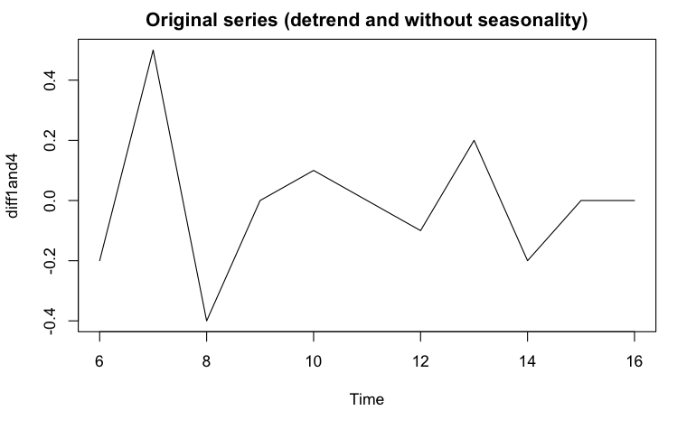

```r
plot.ts(diff1and4, main = "Original series (detrend and without seasonality)")
```

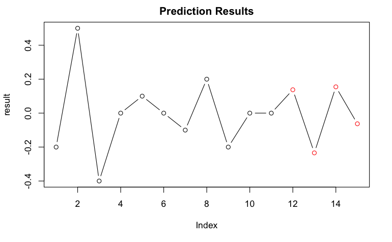

```r
plot(result,type= "b", main = "Prediction Results", col=ifelse(1:length(result) < length(result) - 3, "black", "red"))
```